# Metode Pencarian Akar dengan R

Tim Dosen Matematika Lanjut, Prodi Sarjana Informatika, Universitas Islam Indonesia

12/3/2020

Pada tutorial menggunakan `R` kali ini, kita akan mempraktikkan metode pencarian akar dengan metode *Bisection* (Metode Bagi Dua) dan Metode Newton.

*Library* yang akan kita gunakan adalah `cmna` yang dapat anda akses melalui alamat https://rdrr.io/cran/cmna/.

#### 1. Mempersiapkan `library cmna`

```r
library(cmna)
```

#### 2. Mendefinisikan fungsi dan membuat visualisasi kurva fungsi

```r
f <- function(x) {
  x^3 + 4 * x^2 - 10
}
```

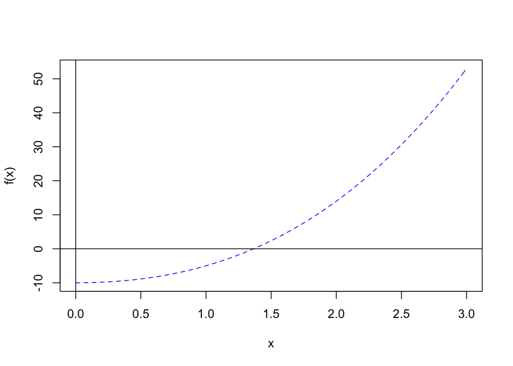

```r
curve(f, xlim=c(0,3), col='blue', lwd=1, lty=2)
abline(h=0)
abline(v=0)
```

#### 3. Metode Bisection

Untuk mencari perkiraan akar dari fungsi $f(x)$ dengan Metode Bagi Dua, gunakan fungsi `bisection` seperti ini,

`bisection(f, a, b, tol = 0.001, m = 100)`.

**Keterangan Argumen**

- f = fungsi
- a = nilai interval pertama
- b = nilai interval kedua
- tol = nilai toleransi error
- m = cacah iterasi maksimal

```r
bisection(f, 1, 2)
```

```
## [1] 1.364746
```

#### 4. Metode Newton

Untuk penyelesaian dengan Metode Newton, terlebih dahulu kita mendefinisikan turunan dari fungsi $f$ menggunakan `library Deriv`.

```r
library(Deriv)
```

Berikut ini adalah proses mendapatkan turunan fungsi $f$.

```r
fp <- Deriv(f)
fp
```

```
## function (x)
## x * (2 * (4 + x) + x)
```

Untuk mencari solusi akar dari sebuah fungsi dengan Metode Newton, gunakan fungsi `newton` dengan cara:

`newton(f, fp, x, tol = 0.001, m = 100)`

**Keterangan Argumen**

- f = fungsi
- fp = fungsi derivasi dari $f$
- x = nilai perkiraan awal
- tol = nilai toleransi error
- m = cacah iterasi maksimal

```r
newton(f, fp, 1.5)
```

```
## [1] 1.36523
```

#### Latihan

1. Gunakan Metode Bisection untuk mencari perkiraan akar dari fungsi-fungsi berikut!
   1. $f(x)= \sqrt{x}-cos x$ pada selang $[0,1]$
   2. $f(x)=3(x+1)(x-\frac{1}{2})(x-1)$ pada selang $[-2,1.5]$ dan [-1.25,2.5]
   3. $f(x)=x^3-2*x^2+14x-6$ pada selang $[0.1];[1,3.2];[3.2,4]$ dengan toleransi error $10^{-2}$
2. Gunakan Metode Newton untuk mencari perkiraan akar fungsi-fungsi berikut!
   1. $f(x)=x^2-6$ dengan inisialisasi awal $p_0=1$
   2. $f(x)=x^3-2*x^2+14x-6$ dengan inisialisasi awal $p_0=1.5$
3. Untuk mengerjakan soal 1 dan 2, silakan anda melakukan *adjustment* terhadap parameter cacah iterasi dan atau toleransi error untuk mendapatkan hasil terbaik!